# Esercizi Modulo 4 - Prima serie

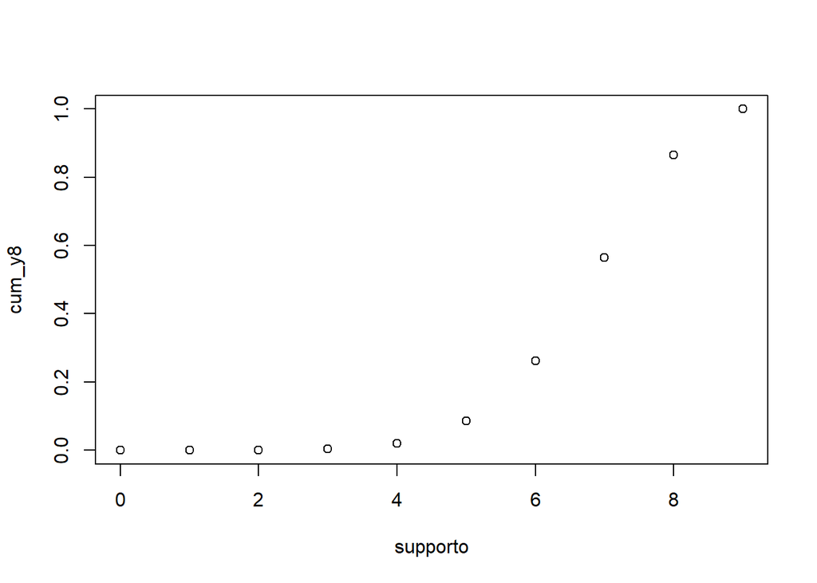

```r
cum_y8 <- pbinom(supporto,size=9,prob=0.8)

plot(supporto,cum_y8)
```

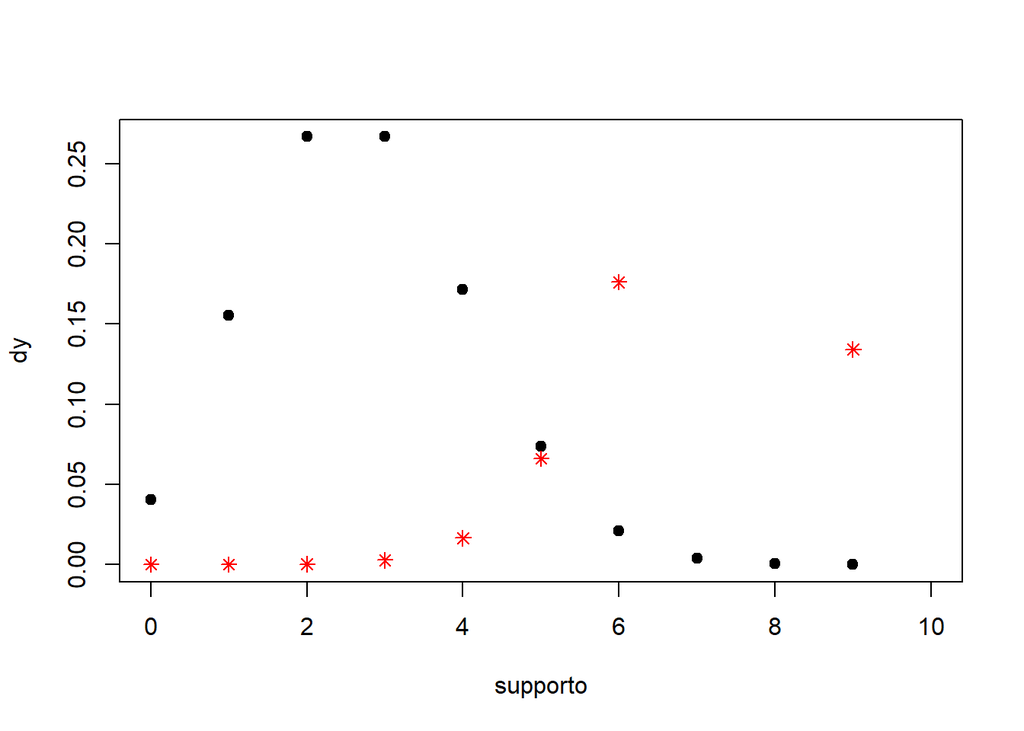

```r
# confronto delle curve
plot(supporto,dy, pch = 19, xlim = c(0, 10))
points(supporto,dy8, pch = 8, col = "red")
```

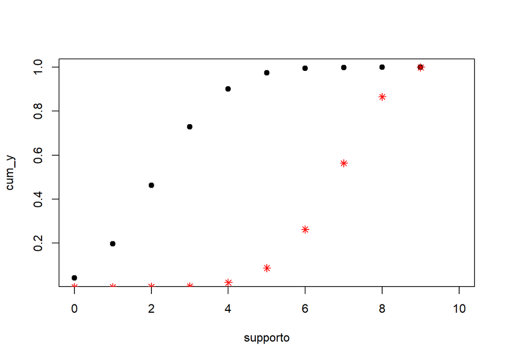

```r
plot(supporto,cum_y, pch = 19, xlim = c(0, 10))
points(supporto,cum_y8, pch = 8, col = "red")
```

## 2.3 3.

Facendo riferimento sempre all’esercizio 1, si calcolino i seguenti quantili:

- quantile associato al valore di probabilità 0.5

```r
qbinom(0.5,size=9,prob=0.3)
```

```
[1] 3
```

```r
qbinom(0.5,size=9,prob=0.3)
```

```
[1] 3
```

- quantile associato al valore di probabilità 0.0975

```r
qbinom(0.0975,size=9,prob=0.3)
```

```
[1] 1
```

## 2.4 4

Si consideri una variabile casuale $Z$ distribuita secondo una distribuzione normale standardizzata. Si calcolino le probabilità dei seguenti eventi:

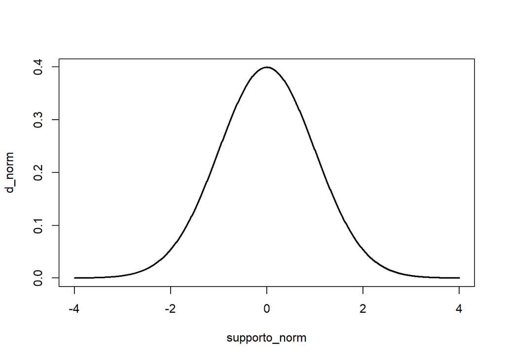

```r
supporto_norm = seq(-4, 4, length.out = 1000)
d_norm = dnorm(supporto_norm)
plot(supporto_norm, d_norm, type ="l", lwd = 2)
```

- $Pr[Z > 0]$

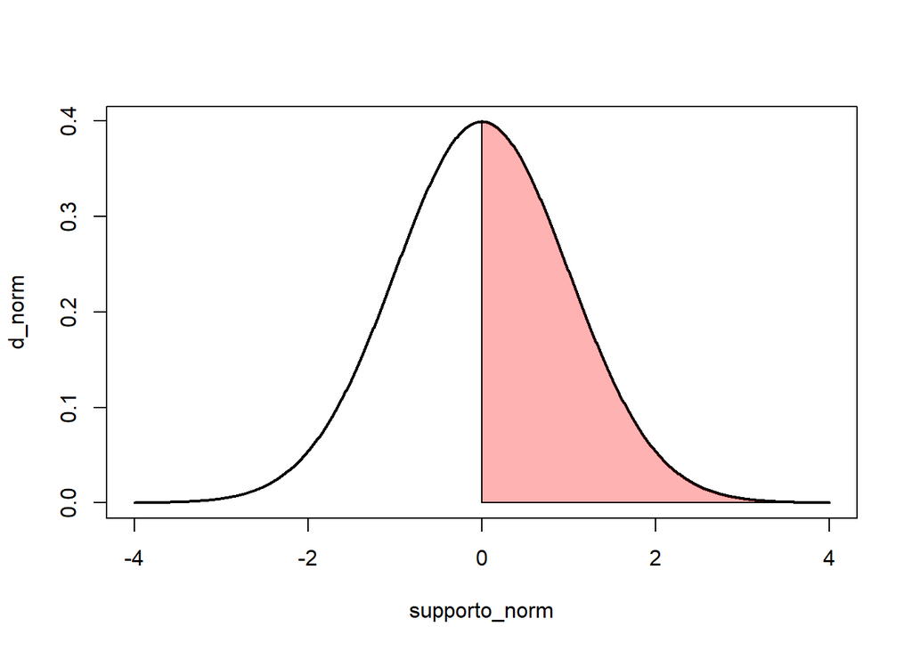

```r
# disegna la curva con solo l'area > 0 colorata
plot(supporto_norm, d_norm, type ="l", lwd = 2)
polygon(c(0, supporto_norm[supporto_norm>0], 4),
        c(0,  dnorm(supporto_norm[supporto_norm >0]), 0),
        col = rgb(1,0,0, 0.3))
```

```r
1 - pnorm(0,mean=0,sd=1)
```

```
[1] 0.5
```

```r
# oppure
pnorm(0,mean=0,sd=1, lower.tail = F)
```

```
[1] 0.5
```

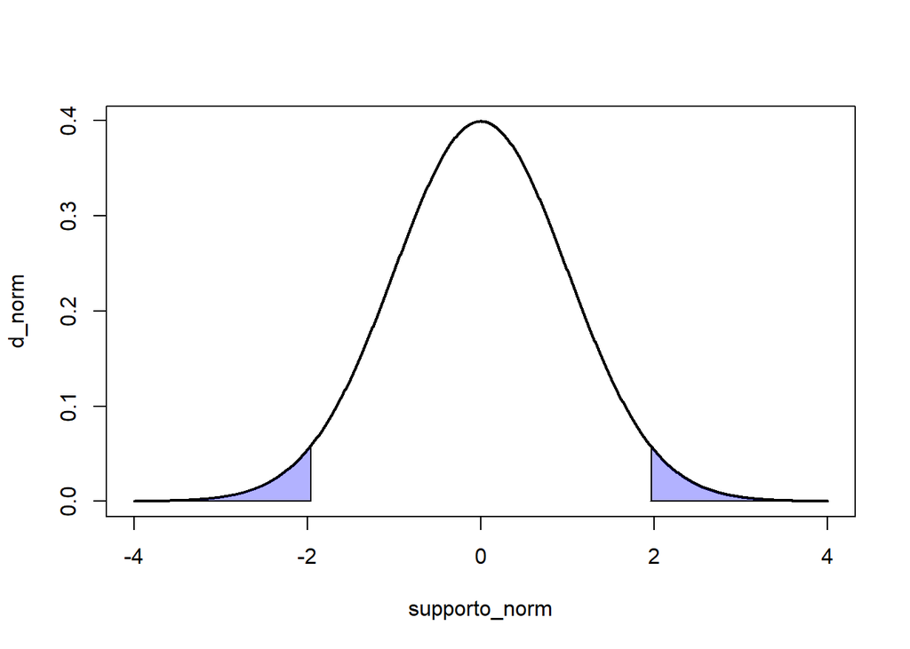

```r
plot(supporto_norm, d_norm, type ="l", lwd = 2)
polygon(c(-4, supporto_norm[supporto_norm<= -1.96],-1.96),
        c(0,  dnorm(supporto_norm[supporto_norm<= -1.96]),0),
        col = rgb(0,0,1, 0.3))
polygon(c(1.96, supporto_norm[supporto_norm>= 1.96], 4),
        c(0,  dnorm(supporto_norm[supporto_norm>= 1.96]),0),
        col = rgb(0,0,1, 0.3))
```

```r
pnorm(-1.96,mean=0,sd=1) + (1 - pnorm(1.96,mean=0,sd=1))
```

```
[1] 0.04999579
```

- $Pr[0 \leq Z \leq 1.5]$

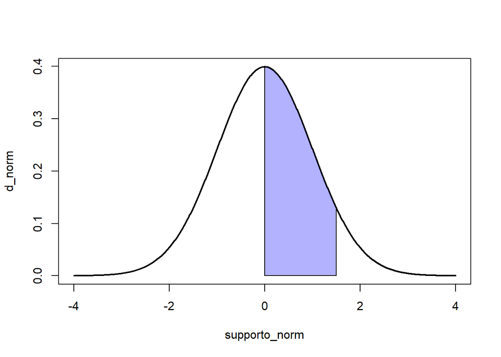

```r
plot(supporto_norm, d_norm, type ="l", lwd = 2)
polygon(c(0, supporto_norm[supporto_norm>= 0 & supporto_norm <= 1.5],1.5),
        c(0,  dnorm(supporto_norm[supporto_norm>= 0 & supporto_norm <= 1.5]),0),
        col = rgb(0,0,1, 0.3))
```

```r
pnorm(1.5,mean=0,sd=1) - (pnorm(0,mean=0,sd=1))
```

```
[1] 0.4331928
```

Dati due intervalli su Z: primo intervallo $[-1,0.5]$ e secondo intervallo $[0,1.5]$, calcolare la probabilità dell’intersezione dei due intervalli.

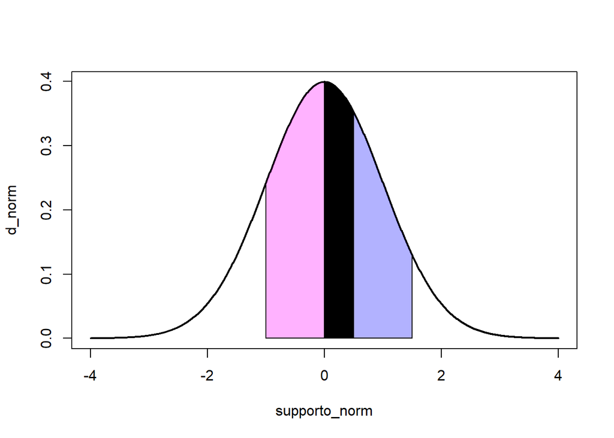

```r
plot(supporto_norm, d_norm, type ="l", lwd = 2)
polygon(c(0, supporto_norm[supporto_norm>= 0 & supporto_norm <= 1.5],1.5),
        c(0,  dnorm(supporto_norm[supporto_norm>= 0 & supporto_norm <= 1.5]),0),
        col = rgb(0,0,1, 0.3))
polygon(c(-1, supporto_norm[supporto_norm>= -1 & supporto_norm <= 0.5],0.5),
        c(0,  dnorm(supporto_norm[supporto_norm>= -1 & supporto_norm <= 0.5]),0),
        col = rgb(1,0,1, 0.3))
# intersezione
polygon(c(0, supporto_norm[supporto_norm>= 0 & supporto_norm <= 0.5],0.5),
        c(0,  dnorm(supporto_norm[supporto_norm>= 0 & supporto_norm <= 0.5]),0),
        col = "black")
```

```r
pnorm(0.5,mean=0,sd=1) - (pnorm(0,mean=0,sd=1))
```

```
[1] 0.1914625
```

Ripetere il precedente esercizio, questa volta calcolando la probabilità dell’unione dei due intervalli.

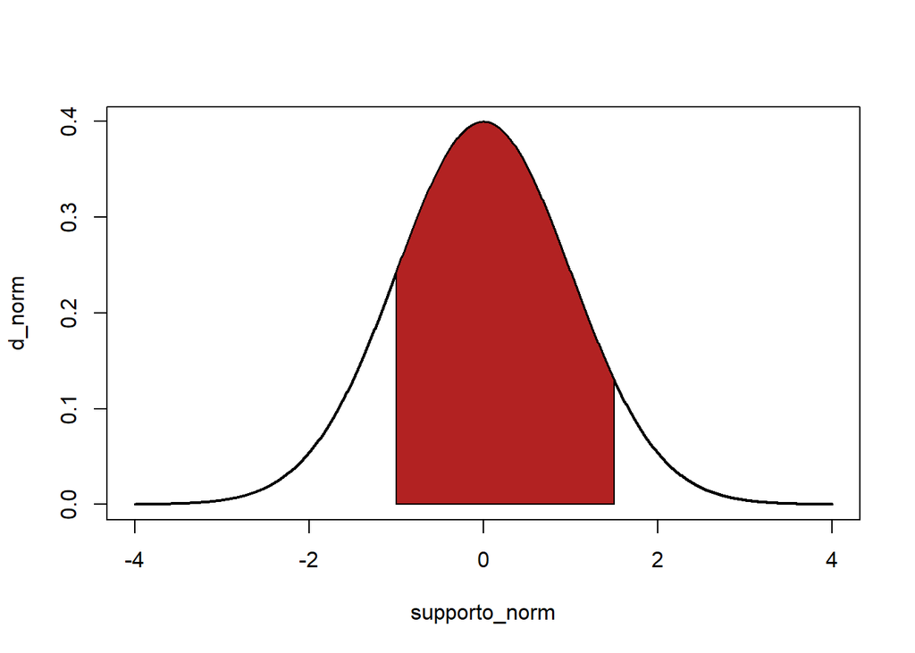

```r
plot(supporto_norm, d_norm, type ="l", lwd = 2)
polygon(c(0, supporto_norm[supporto_norm>= 0 & supporto_norm <= 1.5],1.5),
        c(0,  dnorm(supporto_norm[supporto_norm>= 0 & supporto_norm <= 1.5]),0),
        col = rgb(0,0,1, 0.3))
polygon(c(-1, supporto_norm[supporto_norm>= -1 & supporto_norm <= 0.5],0.5),
        c(0,  dnorm(supporto_norm[supporto_norm>= -1 & supporto_norm <= 0.5]),0),
        col = rgb(1,0,1, 0.3))
# unione
polygon(c(-1, supporto_norm[supporto_norm>= -1 & supporto_norm <= 1.5],1.5),
        c(0,  dnorm(supporto_norm[supporto_norm>= -1 & supporto_norm <= 1.5]),0),
        col = "firebrick")
```

```r
pnorm(1.5,mean=0,sd=1) - pnorm(-1,mean=0,sd=1)
```

```
[1] 0.7745375
```

## 2.5 5.

Fare la somma tra il quantile associato alla probabilità 0.5 di una variabile casuale $T$ distribuita normalmente con media 10 e deviazione standard 5, ed il quantile associato alla probabilità 0.5 di una variabile casuale $S$ distribuita normalmente con media 20 e deviazione standard 10.

```r
qnorm(0.5,mean=10,sd=5) + qnorm(0.5,mean=20,sd=10)
```

```
[1] 30
```

## 2.6 6.

Fare la somma tra il quantile associato alla probabilità 0.2 di una variabile casuale $T2$ distribuita normalmente con media 10 e deviazione standard 5, ed il quantile associato alla probabilità 0.8 di una variabile casuale S2 distribuita normalmente con media 20 e deviazione standard 10.

```r
qnorm(0.2,mean=10,sd=5) + qnorm(0.8,mean=20,sd=10)
```

```
[1] 34.20811
```